# Distribuições de Probabilidade

Guilherme Rodrigues

21 de fevereiro de 2026

```r
options(encoding = "UTF-8")
```

**1)** Em tanques de um pesqueiro, a probabilidade de cada alevino estar com tamanho ideal de comercialização é igual a 0.70. Ao selecionarmos 20 alevinos ao acaso, qual é a probabilidade de observarmos

**a.** no máximo 12 em condições de venda?

**Resposta:** A probabilidade de observarmos no máximo 12 alevinos em condições de venda pode ser calculada usando a distribuição binomial. A fórmula para a probabilidade binomial é dada por:
$$P(X=k) = \binom{n}{k} p^k
(1-p)^{n-k}$$
onde n é o número total de alevinos (20), k é o número de alevinos em condições de venda (12), e p é a probabilidade de um alevino estar em condições de venda (0.70). Utilizando o R, podemos calcular essa probabilidade:

```r
n <- 20
p <- 0.70
k <- 12

prob_max_12 <- sum(dbinom(0:k, n, p))
round(prob_max_12, 3)
```

```
## [1] 0.228
```

Portanto, a probabilidade de observarmos no máximo 12 alevinos em condições de venda é aproximadamente 0.228.

**b.** entre 13 e 17 em condições de venda?

**Resposta:** A probabilidade de observarmos entre 13 e 17 alevinos em condições de venda pode ser calculada somando as probabilidades individuais para k = 13, 14, 15, 16 e 17. Utilizando o R, podemos calcular essa probabilidade:

```r
prob_13_17 <- sum(dbinom(13:17, n, p))
round(prob_13_17, 3)
```

```
## [1] 0.737
```

Portanto, a probabilidade de observarmos entre 13 e 17 alevinos em condições de venda é aproximadamente 0.737.

**c.** pelo menos 16 em condições de venda?

**Resposta:** A probabilidade de observarmos pelo menos 16 alevinos em condições de venda pode ser calculada subtraindo a probabilidade de observarmos no máximo 15 alevinos da unidade. Utilizando o R, podemos calcular essa probabilidade:

```r
prob_pelo_menos_16 <- 1 - sum(dbinom(0:15, n, p))
round(prob_pelo_menos_16, 3)
```

```
## [1] 0.238
```

Portanto, a probabilidade de observarmos pelo menos 16 alevinos em condições de venda é aproximadamente 0.238.

Podemos plotar os gráficos dessas distribuições para melhor visualização:

```r
library(ggplot2)
ensaios <- 0:n
probabilidades <- dbinom(ensaios, n, p)
tabela <- data.frame(ensaios, probabilidades)
tabela
```

| ensaios | probabilidades |
| --- | --- |
| 0 | 3.486784e-11 |
| 1 | 1.627166e-09 |
| 2 | 3.606885e-08 |
| 3 | 5.049639e-07 |
| 4 | 5.007558e-06 |
| 5 | 3.738977e-05 |
| 6 | 2.181070e-04 |
| 7 | 1.017833e-03 |
| 8 | 3.859282e-03 |
| 9 | 1.200665e-02 |

[output cut: 11 more lines]

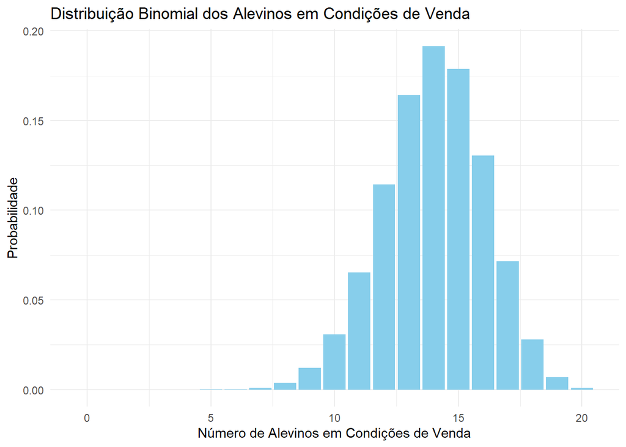

```r
ggplot(tabela, aes(ensaios, probabilidades)) +
  geom_bar(stat = "identity", fill = "skyblue") +
  labs(title = "Distribuição Binomial dos Alevinos em Condições de Venda",
       x = "Número de Alevinos em Condições de Venda",
       y = "Probabilidade") +
  theme_minimal()
```

Podemos observar pelo gráfico que a maior probabilidade está em torno de 13 a 15 alevinos em condições de venda.

**2)** Considere que o número de casos de acidentes envolvendo escorpiões segue uma distribuição Poisson com média de 6 por mês em uma cidade. Calcule a probabilidade, de termos, em um mês

**a.** 7 acidentes?

**Resposta:** A probabilidade de observarmos exatamente 7 acidentes em um mês pode ser calculada usando a distribuição de Poisson. A fórmula para a probabilidade de Poisson é dada por:
$$P(X=k) = \frac{e^{-\lambda}
\lambda^k}{k!}$$
onde $\lambda$ é a média de acidentes (6) e k é o número de acidentes (7). Utilizando o R, podemos calcular essa probabilidade:

```r
lambda <- 6
k <- 7
prob_7_acidentes <- dpois(k, lambda)
round(prob_7_acidentes, 3)
```

```
## [1] 0.138
```

Logo, a probabilidade de termos exatamente 7 acidentes em um mês é aproximadamente 0.138.

**b.** pelo menos 4 acidentes?

**Resposta:** A probabilidade de observarmos pelo menos 4 acidentes em um mês pode ser calculada subtraindo a probabilidade de observarmos no máximo 3 acidentes da unidade. Utilizando o R, podemos calcular essa probabilidade:

```r
prob_pelo_menos_4 <- 1 - sum(dpois(0:3, lambda))
round(prob_pelo_menos_4, 3)
```

```
## [1] 0.849
```

Portanto, a probabilidade de termos pelo menos 4 acidentes em um mês é aproximadamente 0.849.

**c.** No máximo 10 acidentes?

**Resposta:** A probabilidade de observarmos no máximo 10 acidentes em um mês pode ser calculada somando as probabilidades individuais para k = 0, 1, 2, …, 10. Utilizando o R, podemos calcular essa probabilidade:

```r
prob_max_10 <- sum(dpois(0:10, lambda))
round(prob_max_10, 3)
```

```
## [1] 0.957
```

Portanto, a probabilidade de termos no máximo 10 acidentes em um mês é aproximadamente 0.957.

Graficamente, a distribuição de Poisson para o número de casos de acidentes com escorpião pode ser representada da seguinte forma:

```r
ensaios_poisson <- 0:15
probabilidades_poisson <- dpois(ensaios_poisson, lambda)
tabela_poisson <- data.frame(ensaios_poisson, probabilidades_poisson)
tabela_poisson
```

| ensaios_poisson | probabilidades_poisson |
| --- | --- |
| 0 | 0.0024787522 |
| 1 | 0.0148725131 |
| 2 | 0.0446175392 |
| 3 | 0.0892350784 |
| 4 | 0.1338526175 |
| 5 | 0.1606231410 |
| 6 | 0.1606231410 |
| 7 | 0.1376769780 |
| 8 | 0.1032577335 |
| 9 | 0.0688384890 |

[output cut: 6 more lines]

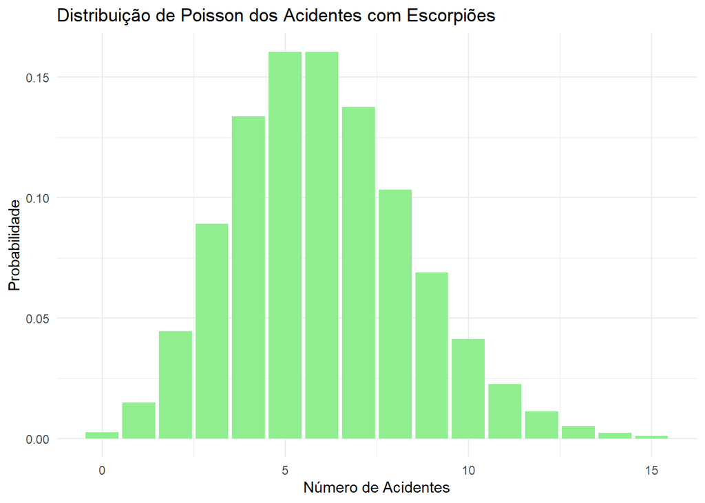

```r
ggplot(tabela_poisson, aes(ensaios_poisson, probabilidades_poisson)) +
  geom_bar(stat = "identity", fill = "lightgreen") +
  labs(title = "Distribuição de Poisson dos Acidentes com Escorpiões",
       x = "Número de Acidentes",
       y = "Probabilidade") +
  theme_minimal()
```

Isso mostra que a probabilidade de ocorrerem entre 5 e 6 acidentes é a mais alta na cidade em questão.

**3)** Suponha que os estágios de câncer no pulmão seguem uma distribuição Multinomial em que p1=0.15, p2=0.25, p3=0.25, p4=0.35, em que $p_i$ representa a probabilidade de selecionar um paciente com câncer no estágio $i$. Ao selecionar 20 pacientes em um grande instituto para tratamento oncológico, qual é a probabilidade de observarmos

**a.** 3, 5, 5 nos estágios 1 a 3 e os demais no estágio 4?

**Resposta:** A distribuição multinomial é dada por
$$P(X_1 = n_1, X_2 = n_2, ..., X_k = n_k) =
\frac{n!}{n_1! n_2! ... n_k!} p_1^{n_1} p_2^{n_2} ... p_k^{n_k}$$
onde $p_i$ é a probabilidade de obter o resultado da classe $i$ em um único ensaio, e $n$ é o número total de ensaios. utilizando o R, temos

```r
n <- 20
p <- c(0.15, 0.25, 0.25, 0.35)
n_values <- c(3, 5, 5, n - sum(c(3, 5, 5)))
prob <- dmultinom(n_values, n, p)
round(prob, 5)
```

```
## [1] 0.01157
```

Logo, a probabilidade de observarmos 3, 5, 5 nos estágios 1 a 3 e os demais no estágio 4 é aproximadamente 0.01157

**b.** 5, 4, 3 nos estágios 1 a 3 e os demais no estágio 4?

**Resposta:** No R, segue que

```r
n_values_b <- c(5, 4, 3, n - sum(c(5, 4, 3)))
prob_b <- dmultinom(n_values_b, n, p)
round(prob_b, 5)
```

```
## [1] 0.00364
```

Logo, a probabilidade de observarmos 5, 4, 3 nos estágios 1 a 3 e os demais no estágio 4 é aproximadamente 0.00364.

**4)** Suponha que o ganho de peso de uma gestante segue uma distribuição Normal com média e desvio-padrão iguais a 13 e 5 quilos. Qual é a probabilidade de uma gestante, selecionada ao acaso, ter um ganho de peso

**a.** menor do que 12 quilos?

**Resposta:** A probabilidade de uma gestante ter um ganho de peso menor do que 12 quilos pode ser calculada usando a distribuição normal. Ela é dada por

$$f(x) = \frac{1}{\sigma \sqrt{2\pi}}
e^{-\frac{(x - \mu)^2}{2\sigma^2}}$$

para $-\infty < x < \infty$, $-\infty < \mu < \infty$ e $\sigma > 0$. Utilizando o R, temos

```r
mu <- 13
sigma <- 5
x <- 12
prob_menor_12 <- pnorm(x, mu, sigma)
round(prob_menor_12, 3)
```

```
## [1] 0.421
```

Logo, a probabilidade de uma gestante ter um ganho de peso menor do que 12 quilos é aproximadamente 0.421.

**b.** maior do que 18 quilos?

**Resposta:** Utilizando o R, temos

```r
x_b <- 18
prob_maior_18 <- 1 - pnorm(x_b, mu, sigma)
round(prob_maior_18, 3)
```

```
## [1] 0.159
```

Logo, a probabilidade de uma gestante ter um ganho de peso maior do que 18 quilos é aproximadamente 0.159.

**c.** entre 13 e 17 quilos?

**Resposta:** Utilizando o R, temos

```r
x1 <- 13
x2 <- 17
prob_entre_13_17 <- pnorm(x2, mu, sigma) - pnorm(x1, mu, sigma)
round(prob_entre_13_17, 3)
```

```
## [1] 0.288
```

Logo, a probabilidade de uma gestante ter um ganho de peso entre 13 e 17 quilos é aproximadamente 0.288.

**d.** qual é o limite do ganho de peso esperado em 15% dos menores ganhos?

**Resposta:** Utilizando o R, temos

```r
limite_15_menores <- qnorm(0.15, mu, sigma)
round(limite_15_menores, 3)
```

```
## [1] 7.818
```

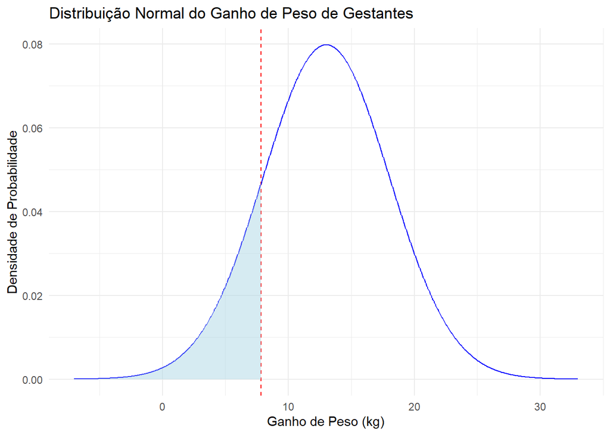

```r
library(ggplot2)
x_vals <- seq(mu - 4*sigma, mu + 4*sigma, length.out = 1000)
y_vals <- dnorm(x_vals, mu, sigma)
tabela_normal <- data.frame(x_vals, y_vals)
ggplot(tabela_normal, aes(x = x_vals, y = y_vals)) +
  geom_vline(xintercept = limite_15_menores, color = "red", linetype = "dashed")+
  geom_line(color = "blue") +
  geom_area(data = subset(tabela_normal, x_vals <= limite_15_menores),
            aes(x = x_vals, y = y_vals), fill = "lightblue", alpha = 0.5) +
  labs(title = "Distribuição Normal do Ganho de Peso de Gestantes",
       x = "Ganho de Peso (kg)",
       y = "Densidade de Probabilidade") +
  theme_minimal()
```

Podemos observar no gráfico a área sombreada que representa os 15% dos menores ganhos de peso. Logo, o limite do ganho de peso esperado em 15% dos menores ganhos é aproximadamente 7.818 quilos.

**e.** qual é o limite do ganho de peso esperado em 5% dos maiores ganhos?

**Resposta:** Utilizando o R, temos

```r
limite_5_maiores <- qnorm(0.95, mu, sigma)
round(limite_5_maiores, 3)
```

```
## [1] 21.224
```

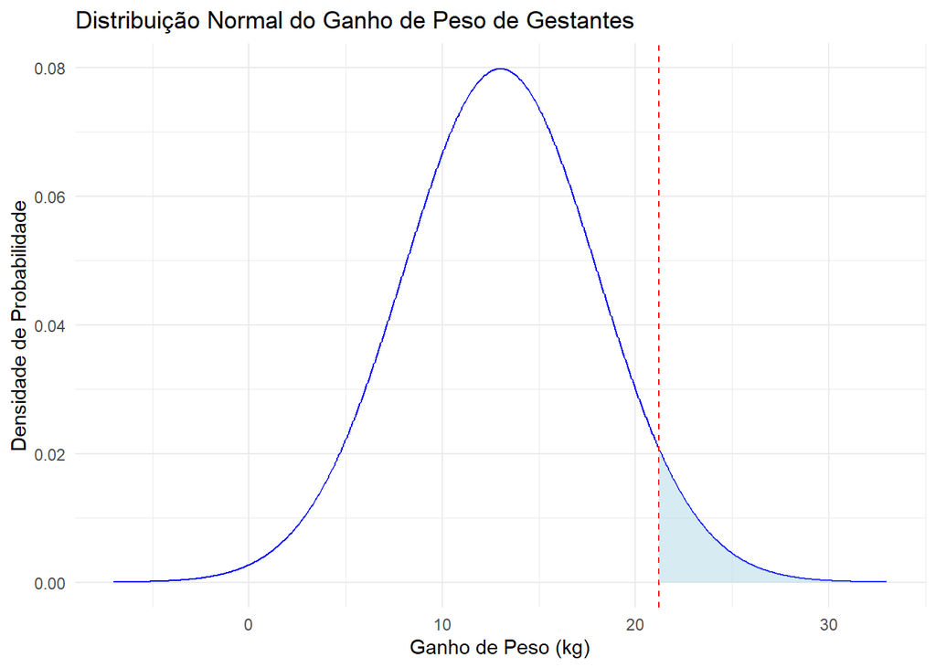

```r
library(ggplot2)
x_vals <- seq(mu - 4*sigma, mu + 4*sigma, length.out = 1000)
y_vals <- dnorm(x_vals, mu, sigma)
tabela_normal <- data.frame(x_vals, y_vals)
ggplot(tabela_normal, aes(x = x_vals, y = y_vals)) +
  geom_line(color = "blue") +
  geom_vline(xintercept = limite_5_maiores, color = "red", linetype = "dashed") +
  geom_area(data = subset(tabela_normal, x_vals >= limite_5_maiores),
            aes(x = x_vals, y = y_vals), fill = "lightblue", alpha = 0.5) +
  labs(title = "Distribuição Normal do Ganho de Peso de Gestantes",
       x = "Ganho de Peso (kg)",
       y = "Densidade de Probabilidade") +
  theme_minimal()
```

Podemos observar que no gráfico a área sombreada que representa os 5% dos maiores ganhos de peso. Logo, o limite do ganho de peso esperado em 5% dos maiores ganhos é aproximadamente 21.224 quilos.

**5)** Calcule os limites dos 2.5% e dos 5% maiores valores das distribuições abaixo.

**a.** Qui-Quadrado com 10 graus de liberdade.

**Resposta:** Utilizando a Tabela de Distribuição Qui-Quadrado para 10 graus de liberdade, encontramos para 2.5% o valor 20.483 e para 5% o valor 18.307. Utilizando o R, temos:

```r
df <- 10
limite_2.5_qui <- qchisq(0.975, df)
limite_5_qui <- qchisq(0.95, df)
c(limite_2.5_qui, limite_5_qui)
```

```
## [1] 20.48318 18.30704
```

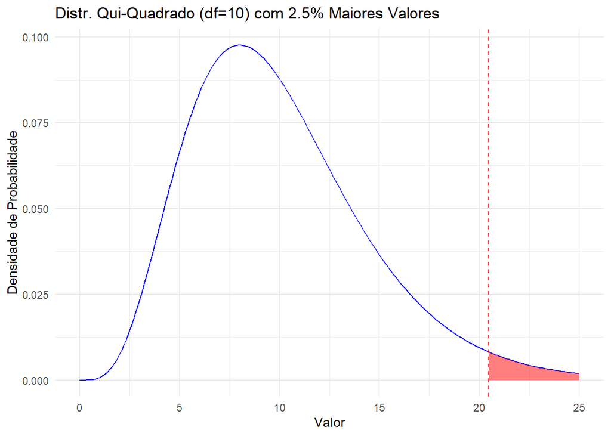

```r
# Visualização da distribuição Qui-Quadrado
library(ggplot2)
tabela_chi <- data.frame(
  x = seq(0, 25, by = 0.1),
  Densidade = dchisq(seq(0, 25, by = 0.1), df = 10)
)
#pintando a região dos 2.5% maiores valores
ggplot(tabela_chi, aes(x=x, y=Densidade)) +
  geom_line(color="blue") +
  geom_area(data=subset(tabela_chi, x >= qchisq(0.975, df = 10)),
            aes(y=Densidade), fill="red", alpha=0.5) +
  geom_vline(xintercept = qchisq(0.975, df = 10),
             linetype="dashed", color="red") +
  labs(title="Distr. Qui-Quadrado (df=10) com 2.5% Maiores Valores",
       x="Valor", y="Densidade de Probabilidade") +
  theme_minimal()
```

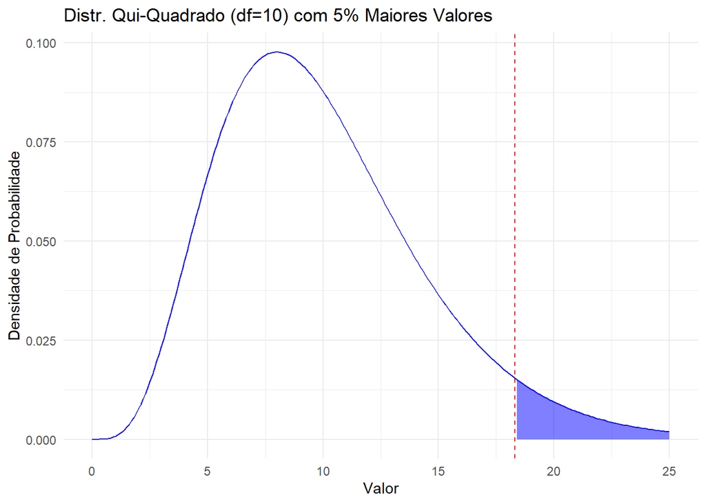

```r
#pintando a região dos 5% maiores valores
ggplot(tabela_chi, aes(x=x, y=Densidade)) +
  geom_line(color="blue") +
  geom_area(data=subset(tabela_chi, x >= qchisq(0.95, df = 10)),
            aes(y=Densidade), fill="blue", alpha=0.5) +
  geom_vline(xintercept = qchisq(0.95, df = 10),
             linetype="dashed", color="red") +
  labs(title="Distr. Qui-Quadrado (df=10) com 5% Maiores Valores",
       x="Valor", y="Densidade de Probabilidade") +
  theme_minimal()
```

Logo, utilizando o R, temos que os limites dos 2.5% e dos 5% maiores valores da distribuição Qui-Quadrado com 10 graus de liberdade são aproximadamente 20.48318 e 18.30704, respectivamente. Podemos comparar esses resultados com os tabelados como segue:

| Percentil | Valor Tabelado | Valor Calculado |
| --- | --- | --- |
| 2.5% | 20.483 | 20.48318 |
| 5.0% | 18.307 | 18.30704 |

A Tabela mostra que os resultados são iguais, até a terceira casa decimal.

**b.** t de Student com 15 graus de liberdade.

**Resposta:** Utilizando a tabela t-student, temos que para 15 graus de liberdade, os limites dos 2.5% e 5% maiores valores são 2.131 e 1.753, respectivamente. Utilizando o R, temos

```r
limite_2.5_t <- qt(0.025, df = 15, lower.tail = FALSE)
limite_5_t <- qt(.05, df = 15, lower.tail = FALSE)
c(limite_2.5_t, limite_5_t)
```

```
## [1] 2.13145 1.75305
```

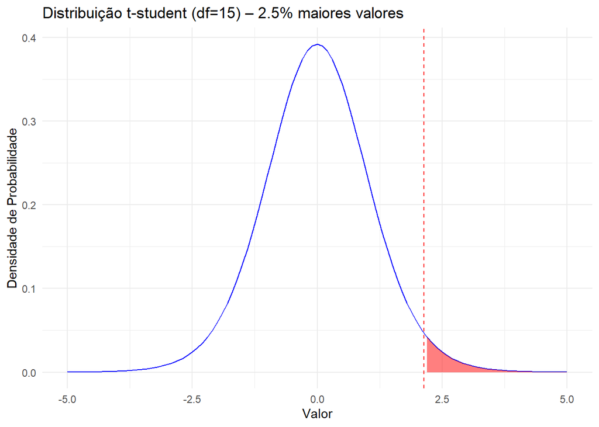

```r
# tabela da densidade t com 15 g.l.
x_vals <- seq(-5, 5, by = 0.1)
tabela_t <- data.frame(
  x = x_vals,
  Densidade = dt(x_vals, df = 15)
)

# plotando região dos 2.5% maiores
ggplot(tabela_t, aes(x = x, y = Densidade)) +
  geom_line(color = "blue") +
  geom_area(
    data = subset(tabela_t, x >= limite_2.5_t),
    aes(x = x, y = Densidade),
    fill = "red", alpha = 0.5
  ) +
  geom_vline(xintercept = limite_2.5_t, linetype = "dashed", color = "red") +
  labs(
    title = "Distribuição t-student (df=15) – 2.5% maiores valores",
    x = "Valor", y = "Densidade de Probabilidade"
  ) +  theme_minimal()
```

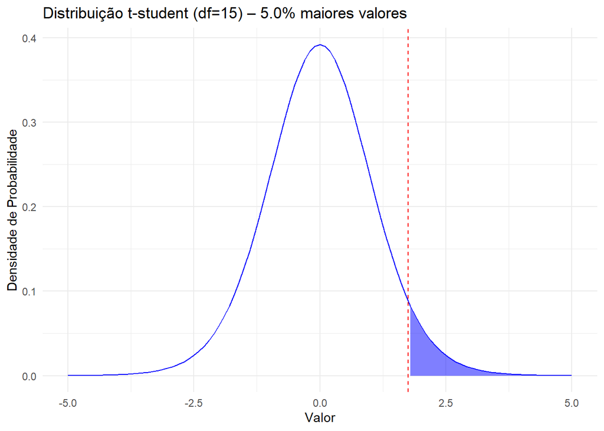

```r
# plotando região dos 5% maiores
ggplot(tabela_t, aes(x = x, y = Densidade)) +
  geom_line(color = "blue") +
  geom_area(
    data = subset(tabela_t, x >= limite_5_t),
    aes(x = x, y = Densidade),
    fill = "blue", alpha = 0.5
  ) +
  geom_vline(xintercept = limite_5_t, linetype = "dashed", color = "red") +
  labs(
    title = "Distribuição t-student (df=15) – 5.0% maiores valores",
    x = "Valor", y = "Densidade de Probabilidade"
  ) +
  theme_minimal()
```

Logo, utilizando o R, temos que os limites dos 2.5% e dos 5% maiores valores da distribuição t-student com 15 graus de liberdade são aproximadamente 2.13145 e 1.75305, respectivamente. Podemos comparar esses resultados com os tabelados como segue:

| Percentil | Valor Tabelado | Valor Calculado |
| --- | --- | --- |
| 2.5% | 2.131 | 2.13145 |
| 5.0% | 1.753 | 1.75305 |

A Tabela mostra que os resultados são iguais, até a terceira casa decimal.

**c.** F com 10 e 12 graus de liberdade no numerador e denominador, respectivamente.

**Resposta:** Utilizando a tabela F, temos que para $v_1=10$ e $v_2=12$ graus de liberdade, os limites dos 2.5% é 3.37. A tabela F fornecida fornece os valores $f_c$ tais que $P(F>f_c)=0.025$, isto é, 2.5%. Logo, para o limite de 5% utilizaremos o R. Segue que

```r
library(ggplot2)

# Graus de liberdade
df1 <- 10
df2 <- 12

# Quantis de cauda superior
limite_2.5_f <- qf(0.975, df1 = df1, df2 = df2)  # 2,5% maiores
limite_5_f   <- qf(0.95,  df1 = df1, df2 = df2)  # 5% maiores

c(limite_2.5_f, limite_5_f)
```

```
## [1] 3.373553 2.753387
```

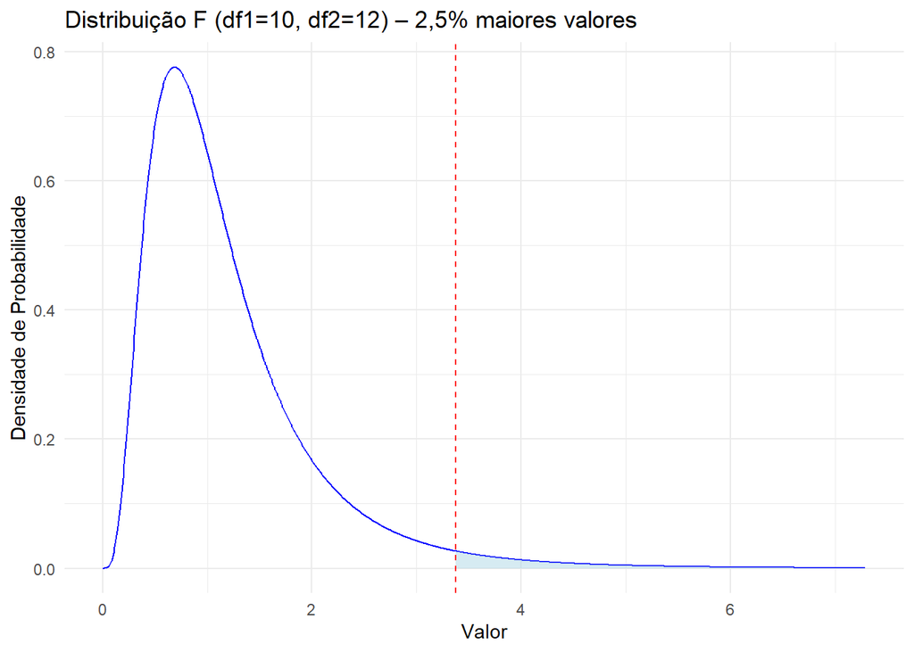

```r
# Sequência para plot
x_vals <- seq(0, qf(0.999, df1 = df1, df2 = df2), length.out = 1200)
tabela_f <- data.frame(
  x = x_vals,
  Densidade = df(x_vals, df1 = df1, df2 = df2)
)

# Gráfico para 2,5% maiores valores
ggplot(tabela_f, aes(x = x, y = Densidade)) +
  geom_line(color = "blue") +
  geom_area(
    data = subset(tabela_f, x >= limite_2.5_f),
    aes(x = x, y = Densidade),
    fill = "lightblue", alpha = 0.5
  ) +
  geom_vline(xintercept = limite_2.5_f, linetype = "dashed", color = "red") +
  labs(
    title = sprintf("Distribuição F (df1=%d, df2=%d) – 2,5%% maiores valores", df1, df2),
    x = "Valor", y = "Densidade de Probabilidade"
  ) +
  theme_minimal()
```

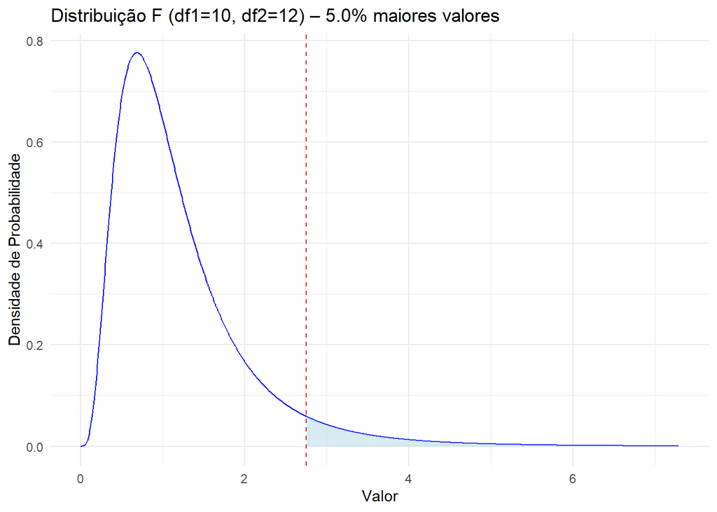

```r
# Gráfico para 2,5% maiores valores
ggplot(tabela_f, aes(x = x, y = Densidade)) +
  geom_line(color = "blue") +
  geom_area(
    data = subset(tabela_f, x >= limite_5_f),
    aes(x = x, y = Densidade),
    fill = "lightblue", alpha = 0.5
  ) +
  geom_vline(xintercept = limite_5_f, linetype = "dashed", color = "red") +
  labs(
    title = sprintf("Distribuição F (df1=%d, df2=%d) – 5.0%% maiores valores", df1, df2),
    x = "Valor", y = "Densidade de Probabilidade"
  ) +
  theme_minimal()
```

Podemos ver que com relação ao quantil de 2.5%, o valor calculado pelo R foi igual ao observado na tabela, a menos das casas decimais. Já com relação ao aos limites de 5.0% dos maiores valores temos como resultado 2.753387.